# APIs and Database Queries

## Grading Exercises

Remember that you grade your own exercises using the rubric specified in each posted exercise solution, adding comments (using the comment feature for Word documents) where your solution differs from the posted solution.

## Marketing Analytics Process

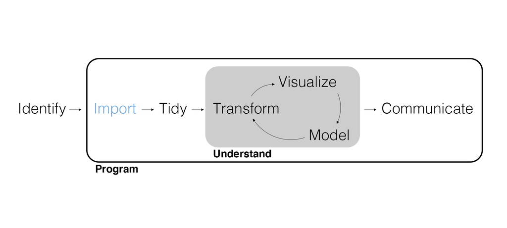

[figure not shown]

## Motivating Example

Patagonia is very impressed with what we’ve been able to do with their in-house data. They have decided to open up additional data sources for us so we can expand our analyses. Patagonia recently used Qualtrics to administer a survey to some of their customers. This survey data will need to be accessed using an API. The second additional source contains information on the revenue from each customer. This data is stored in a SQL data base.

- Has anyone used or accessed a database before?
- What about an API?

## Computer Orientation

R’s performance is primarily based on your *available* **RAM** and secondarily on your **CPU**. In RStudio, the Environment uses RAM while Files gives you access to the **hard drive**.

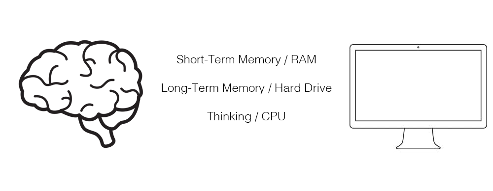

The hard drive (i.e., hard disk) is used for:

- Installing packages.
- Writing and rendering files.

RAM (i.e., random access memory) is used for:

- Loading packages.
- Importing, wrangling, visualizing, and modeling.

## Files and Folders

A hard drive is composed of **files** (e.g., .csv, .rds, .R, .qmd, .exe) organized into **folders**/**directories**. It is critical to organize your work. Create a folder for your:

- Notes
- Data
- Exercises
- Projects

Every file on your computer has a kind of address called a **file path**.

## RStudio Projects

When we want to import or save data or reference another file on the hard drive, R needs to know *where* to look. RStudio projects help organize our work.

Whenever you have this project open in RStudio, the folder/directory where the project file is will be R’s **working directory**, the folder where R looks when interacting with files.

To create an R project, click on the blue cube with an R in it at the top left of your screen in R. You should see this box pop up, and you can either choose to start a new folder, or use an existing folder.

[figure not shown]

When you initiate an R project, R creates a .Rproj file. When you open a .Rproj file, your working directory becomes the folder where the .Rproj file lives.

## Your Turn!

Take a second to organize your files for this class in the way I’ve just described. You may wish to create three folders within your main MKTG 411 folder, one for each unit, and then include sub-folders for notes, data, exercises, and projects within each. For future exercises and projects, starting with the one for exercise 6, include a .Rproj file in your folder to help you easily access the working directory you need.

## APIs

**APIs** (Application Programming Interfaces) are a *general* way to access any server that provide permission to access data along with securely controlling what and how much data you can access.

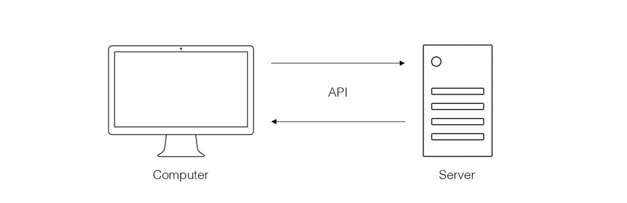

## API Clients

To use an API you should use an **API client** specific to the server. There are a plethora of R packages that provide API clients for specific servers (e.g., {twitteR}, {Rfacebook}, {RGoogleAnalytics}, {WikipediR}, {qualtRics}). API clients differ, but they typically require at least:

- Key: An API key is like a username that can change.
- Token: An API token is like a password that can change.

## Use an API

Install and load the {qualtRics} package so that we can access the survey data.

In the console (NOT a code chunk), call the following:

```r
qualtRics::qualtrics_api_credentials(
  api_key = "Ir2JDPvhOjSmMIpWo8bwVUAbvPs6uwGqIKipAuo6",
  base_url = "sjc1.qualtrics.com",
  install = TRUE
)
```

## What Did We Just Do?

Let’s draw it out.

## Import Data

We can see what surveys are available to download.

```r
all_surveys()
```

We can import data using the survey ID.

```r
survey_data <- fetch_survey("SV_8B5zozRL3hVr8dU")

survey_data
```

## Let’s AVOID Reconnecting to the API - Write Your Data to your Hard Drive

```r
# This code "writes" the data, which means it gets saved locally on your
# computer instead of just in this R session.

# Write it as a CSV to use outside of R.
survey_data |>
  write_csv("example_qualtrics_survey.csv")
```

## Your Turn!

Fetch the “Hammocks and Life” survey and write it to your local hard drive. Hint: they survey ID is `SV_73xYIxZuxsqAx6Z`.

## Expected Survey

[output not shown]

## Expected Survey

```r
hammock_survey_data
```

```
## # A tibble: 141 × 132
##    StartDate           EndDate             Status     IPAddress       Progress
##    <dttm>              <dttm>              <chr>      <chr>              <dbl>
##  1 2016-10-22 08:18:37 2016-10-22 08:30:31 IP Address 208.117.124.24       100
##  2 2016-10-22 09:57:55 2016-10-22 10:08:21 IP Address 24.111.133.43        100
##  3 2016-10-22 10:19:46 2016-10-22 10:29:46 IP Address 67.2.81.30           100
##  4 2016-10-22 10:21:57 2016-10-22 10:29:51 IP Address 174.23.245.194       100
##  5 2016-10-22 10:25:34 2016-10-22 10:31:43 IP Address 107.188.142.119      100
##  6 2016-10-22 10:25:23 2016-10-22 10:33:23 IP Address 73.98.128.211        100
##  7 2016-10-22 10:38:37 2016-10-22 10:46:59 IP Address 174.52.253.239       100
##  8 2016-10-22 10:42:43 2016-10-22 10:51:40 IP Address 67.172.248.218       100
##  9 2016-10-22 11:13:24 2016-10-22 11:22:39 IP Address 71.199.60.41         100
## 10 2016-10-22 11:10:52 2016-10-22 11:25:42 IP Address 67.2.32.96           100
## # ℹ 131 more rows
## # ℹ 127 more variables: `Duration (in seconds)` <dbl>, Finished <lgl>,
## #   RecordedDate <dttm>, ResponseId <chr>, RecipientLastName <lgl>,
## #   RecipientFirstName <lgl>, RecipientEmail <lgl>, ExternalReference <lgl>,
## #   LocationLatitude <dbl>, LocationLongitude <dbl>, DistributionChannel <chr>,
## #   UserLanguage <chr>, Q3 <dbl>, Q4_1 <chr>, Q4_2 <chr>, Q4_3 <chr>,
## #   Q4_4 <chr>, Q4_5 <chr>, Q5_1 <chr>, Q5_2 <chr>, Q5_3 <chr>, Q5_4 <chr>, …
```

## Solution

```r
hammock_survey_data <- fetch_survey("SV_73xYIxZuxsqAx6Z")

hammock_survey_data |>
  write_csv("example_hammock_survey.csv")
```

## Databases and SQL Disclaimer

Unfortunately, AWS is being difficult and was not able to set up an example data base for us to use.

HOWEVER…

The process (and principles) are extremely similar to accessing an API. So, we’ll look at example code and call it good!

## Databases and SQL

As the size and complexity of data grow, it is more likely to be housed on a **database**, a computer or **server** formatted specifically to house data (relational and otherwise). We communicate with a database using **queries** composed in **SQL** (Structured Query Language).

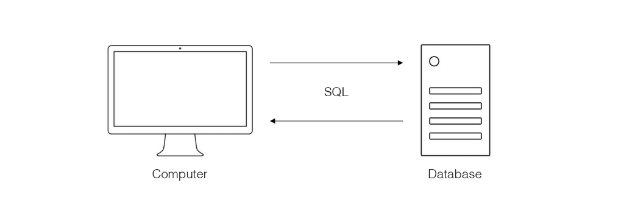

## SQL Backends

There are a number of different types of databases or **backends**: MySQL, PostgreSQL, RSQLite, etc. Each backend requires its own dialect of SQL.

So we need to not only know SQL, we need to know a specific backend in order to just import data from a database.

## Simple Queries

While it probably is a good idea to learn some SQL and specific backends, for *simple queries* we can write {dplyr} code that {dbplyr} will translate into a query in a specific backend for us. These two package names are similar, but they’re not to be confused. We’ve already worked with {dplyr}, and now we are introducing {dbplyr}.

## Install and Load Packages

```r
library(tidyverse) # tidyverse packages, including dplyr.
library(dbplyr)    # dbplyr translates dplyr into SQL.
library(DBI)       # DBI manages the database connection.
```

## Connect to a Database

This code saves our process for connecting to the database within a variable we’ll call “connection.” Because it is bad practice to include the password within our document, we are telling R to give us a pop-up window where we can enter the password each time. The password is `practicemakes`.

```r
connection <- dbConnect(
  RPostgreSQL::PostgreSQL(),
  dbname = "analyticsdb",
  host = "analyticsdb.ccutuqssh92k.us-west-2.rds.amazonaws.com",
  port = 5432,
  user = "quantmktg",
  password = rstudioapi::askForPassword("Database password")
)

connection
```

```
<PostgreSQLConnection>
```

## Data Tables

List the **data tables** (the database’s “data frames”) on the database. Large data like those stored in a CRM system typically need to be stored in separate data tables.

```r
dbListTables(connection)
```

```
[1] "customer_data" "store_revenue"
```

Print a data table. What’s different?

```r
tbl(connection, "store_revenue")
```

[output not shown]

## Query a Database

It can be **computationally expensive** to query a database so {dbplyr} doesn’t execute a query until you ask for data.

```r
data_db <- tbl(connection, "customer_data") |>
  filter(region == "West") |>
  group_by(state) |>
  summarize(
    n = n(),
    avg_income = mean(income),
    avg_credit = mean(credit)
  )

data_db
```

[output not shown]

View the SQL using `show_query()`.

```r
data_db |>
  show_query()
```

```
<SQL>
SELECT
  "state",
  COUNT(*) AS "n",
  AVG("income") AS "avg_income",
  AVG("credit") AS "avg_credit"
FROM "customer_data"
WHERE ("region" = 'West')
GROUP BY "state"
```

## Import Data and Disconnect

Once you have the wrangled the data you need, import it using `collect()`.

```r
store_revenue <- tbl(connection, "store_revenue") |>
  collect()
```

Finally, **always disconnect** from a database when you are finished.

```r
dbDisconnect(connection)
```

```
[1] TRUE
```

## Write Data

Similar to APIs, once we have the data we need we can write it locally.

```r
# Write it as a CSV to use outside of R.
store_revenue |>
  select(-row.names) |>
  write_csv("Data", "store_revenue.csv")
```

## Good Practices

We’ve discussed a few good practices when it comes to importing data:

- Disconnect from databases after importing data.
- Don’t save sensitive credentials in your code.
- Write data locally (with permission) once it’s been imported.

When we import data from a server in Quarto, every time we render the document it will re-execute and eat up server bandwidth (i.e., database access or API calls). It’s better to do this once and then, if we need to show how we got the data, include the code with the relevant cell set to `#| eval: false`.

## Live Coding Exercise

Patagonia currently measures the overall satisfaction level of customers and the likelihood that customers would recommend the store. While these measures have been frequently collected by the company, they don’t have a clear idea of whether they are related to outcomes the company truly cares about, such as revenue. Our task is to investigate these survey results and to determine whether Patagonia should continue to collect these survey responses (and analyze them further) or look for other ways of assessing the customer experience.

(Let’s treat this as a mini-project).

## Wrapping Up

*Summary*

- Discussed APIs and databases.

*Next Time*

- Dashboards

*Supplementary Material*

- *R for Data Science (2e)* Chapters 9 and 23

*Artwork by @allison_horst*

## Exercise 6

Patagonia has requested that we re-do our RFM analysis now that we have access to the revenue per month per customer. In RStudio, create a new Quarto document and do the following.

1. Let’s define customers who have “high monetary value” as anyone who has spent more than $25,000 total. In its own section of the report, use the `store_revenue` data to identify these customers. How many “high monetary value” customers are there?
2. In its own section of the report, report on the composition of these customers by visualizing the relationship between their total revenue, credit, gender, and marital status all in a single visualization. Report on what you discover.
3. Render the Quarto document into Word, export the Word document, and upload to Canvas.